# Project: Investigate a Dataset

- Introduction
- Data Wrangling
- Exploratory Data Analysis
- Conclusions

## Introduction

> Selected the TMDB Dataset for this project

```python
import pandas as pd
import numpy as np
import matplotlib.pyplot as plt
import seaborn as sns
import csv
%matplotlib inline
```

## Data Wrangling

### General Properties

```python
df = pd.read_csv(r'C:\Users\Archit\Desktop\data science\Udacity Data Analyst Nano Degreee\P3. Investigate a Dataset\Movies Database\tmdb-movies.csv', index_col='id')
print(df.info())
```

```
<class 'pandas.core.frame.DataFrame'>
Int64Index: 10866 entries, 135397 to 22293
Data columns (total 20 columns):
imdb_id                 10856 non-null object
popularity              10866 non-null float64
budget                  10866 non-null int64
revenue                 10866 non-null int64
original_title          10866 non-null object
cast                    10790 non-null object
homepage                2936 non-null object
director                10822 non-null object
tagline                 8042 non-null object
keywords                9373 non-null object
overview                10862 non-null object
runtime                 10866 non-null int64
genres                  10843 non-null object
production_companies    9836 non-null object
release_date            10866 non-null object
vote_count              10866 non-null int64
vote_average            10866 non-null float64
release_year            10866 non-null int64
budget_adj              10866 non-null float64
revenue_adj             10866 non-null float64
dtypes: float64(4), int64(5), object(11)
memory usage: 1.7+ MB
None
```

```python
print(df.shape)
```

```
(10866, 20)
```

```python
df.head()
```

| id | imdb_id | popularity | budget | revenue | original_title | cast | homepage | director | tagline | keywords | overview | runtime | genres | production_companies | release_date | vote_count | vote_average | release_year | budget_adj | revenue_adj |
| --- | --- | --- | --- | --- | --- | --- | --- | --- | --- | --- | --- | --- | --- | --- | --- | --- | --- | --- | --- | --- |
| 135397 | tt0369610 | 32.985763 | 150000000 | 1513528810 | Jurassic World | Chris Pratt\|Bryce Dallas Howard\|Irrfan Khan\|Vi... | http://www.jurassicworld.com/ | Colin Trevorrow | The park is open. | monster\|dna\|tyrannosaurus rex\|velociraptor\|island | Twenty-two years after the events of Jurassic ... | 124 | Action\|Adventure\|Science Fiction\|Thriller | Universal Studios\|Amblin Entertainment\|Legenda... | 6/9/15 | 5562 | 6.5 | 2015 | 1.379999e+08 | 1.392446e+09 |
| 76341 | tt1392190 | 28.419936 | 150000000 | 378436354 | Mad Max: Fury Road | Tom Hardy\|Charlize Theron\|Hugh Keays-Byrne\|Nic... | http://www.madmaxmovie.com/ | George Miller | What a Lovely Day. | future\|chase\|post-apocalyptic\|dystopia\|australia | An apocalyptic story set in the furthest reach... | 120 | Action\|Adventure\|Science Fiction\|Thriller | Village Roadshow Pictures\|Kennedy Miller Produ... | 5/13/15 | 6185 | 7.1 | 2015 | 1.379999e+08 | 3.481613e+08 |
| 262500 | tt2908446 | 13.112507 | 110000000 | 295238201 | Insurgent | Shailene Woodley\|Theo James\|Kate Winslet\|Ansel... | http://www.thedivergentseries.movie/#insurgent | Robert Schwentke | One Choice Can Destroy You | based on novel\|revolution\|dystopia\|sequel\|dyst... | Beatrice Prior must confront her inner demons ... | 119 | Adventure\|Science Fiction\|Thriller | Summit Entertainment\|Mandeville Films\|Red Wago... | 3/18/15 | 2480 | 6.3 | 2015 | 1.012000e+08 | 2.716190e+08 |
| 140607 | tt2488496 | 11.173104 | 200000000 | 2068178225 | Star Wars: The Force Awakens | Harrison Ford\|Mark Hamill\|Carrie Fisher\|Adam D... | http://www.starwars.com/films/star-wars-episod... | J.J. Abrams | Every generation has a story. | android\|spaceship\|jedi\|space opera\|3d | Thirty years after defeating the Galactic Empi... | 136 | Action\|Adventure\|Science Fiction\|Fantasy | Lucasfilm\|Truenorth Productions\|Bad Robot | 12/15/15 | 5292 | 7.5 | 2015 | 1.839999e+08 | 1.902723e+09 |
| 168259 | tt2820852 | 9.335014 | 190000000 | 1506249360 | Furious 7 | Vin Diesel\|Paul Walker\|Jason Statham\|Michelle ... | http://www.furious7.com/ | James Wan | Vengeance Hits Home | car race\|speed\|revenge\|suspense\|car | Deckard Shaw seeks revenge against Dominic Tor... | 137 | Action\|Crime\|Thriller | Universal Pictures\|Original Film\|Media Rights ... | 4/1/15 | 2947 | 7.3 | 2015 | 1.747999e+08 | 1.385749e+09 |

### Data Cleaning

> 1. Creating a new dataset with only those columns which are relevant to the analysis
> 2. Removing duplicate entries from the new dataset
> 3. Checked for null values in all columns

```python
# Dropping columns not needed for analysis

df_a = df.drop(['budget', 'revenue', 'cast', 'homepage', 'tagline', 'keywords', 'overview', 'production_companies', 'release_date'], axis=1)
```

```python
# Dropping any duplicate rows in the dataset

df_a.drop_duplicates(inplace = True)
print(df_a.shape)
```

```
(10865, 11)
```

```python
# Checking for any missing values

df_a.isnull().sum()
```

```
imdb_id           10
popularity         0
original_title     0
director          44
runtime            0
genres            23
vote_count         0
vote_average       0
release_year       0
budget_adj         0
revenue_adj        0
dtype: int64
```

```python
# Dropping missing values in imdb_id

df_a.dropna(subset=['imdb_id'], inplace=True)
print(df_a.shape)
df_a.head()
```

```
(10855, 11)
```

| id | imdb_id | popularity | original_title | director | runtime | genres | vote_count | vote_average | release_year | budget_adj | revenue_adj |
| --- | --- | --- | --- | --- | --- | --- | --- | --- | --- | --- | --- |
| 135397 | tt0369610 | 32.985763 | Jurassic World | Colin Trevorrow | 124 | Action\|Adventure\|Science Fiction\|Thriller | 5562 | 6.5 | 2015 | 1.379999e+08 | 1.392446e+09 |
| 76341 | tt1392190 | 28.419936 | Mad Max: Fury Road | George Miller | 120 | Action\|Adventure\|Science Fiction\|Thriller | 6185 | 7.1 | 2015 | 1.379999e+08 | 3.481613e+08 |
| 262500 | tt2908446 | 13.112507 | Insurgent | Robert Schwentke | 119 | Adventure\|Science Fiction\|Thriller | 2480 | 6.3 | 2015 | 1.012000e+08 | 2.716190e+08 |
| 140607 | tt2488496 | 11.173104 | Star Wars: The Force Awakens | J.J. Abrams | 136 | Action\|Adventure\|Science Fiction\|Fantasy | 5292 | 7.5 | 2015 | 1.839999e+08 | 1.902723e+09 |
| 168259 | tt2820852 | 9.335014 | Furious 7 | James Wan | 137 | Action\|Crime\|Thriller | 2947 | 7.3 | 2015 | 1.747999e+08 | 1.385749e+09 |

```python
df_a.info()
```

```
<class 'pandas.core.frame.DataFrame'>
Int64Index: 10855 entries, 135397 to 22293
Data columns (total 11 columns):
imdb_id           10855 non-null object
popularity        10855 non-null float64
original_title    10855 non-null object
director          10815 non-null object
runtime           10855 non-null int64
genres            10834 non-null object
vote_count        10855 non-null int64
vote_average      10855 non-null float64
release_year      10855 non-null int64
budget_adj        10855 non-null float64
revenue_adj       10855 non-null float64
dtypes: float64(4), int64(3), object(4)
memory usage: 1017.7+ KB
```

## Exploratory Data Analysis

### Research Question 1. Since beginning of the data, which directors directed the most popular movies in the dataset?

```python
#Drop rows with missing information about director
df_dir = df_a.dropna(subset=['director'])
df_dir['director'].nunique()
```

```
5064
```

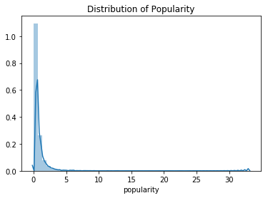

```python
#Checking the ditrbution for popularity of movies
#Majority(99%) of the movies were below the popularity index of 5
x = sns.distplot(df_dir['popularity'])
x.axes.set_title("Distribution of Popularity");
```

```python
#5064 out of 10815 entries for directors are unique
#Let us try to find out the directors for whom we have a sufficient sample for fair comparison
#Let us consider 10 as a fair sample
df_dir1 = df_dir.groupby('director').filter(lambda x: len(x) >= 10)
```

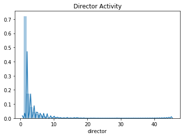

```python
#Checking distribution of director activity (number of movies released)
#From the chart we can observe that only a small fraction of the directors were more active than our chosen threshold (10 movies)
x = sns.distplot(df_dir['director'].value_counts())
x.axes.set_title("Director Activity");
```

```python
#Quick check
df_dir1['director'].value_counts()[-1]
```

```
10
```

```python
#Calculate the mean popularity of the movies directed by the selected directors
print('Popularity (Top 5): ')
print(df_dir1.groupby('director')['popularity'].mean().nlargest(5))
print()
print('Number of movies in database (Top 5): ')
print(df_dir1['director'].value_counts()[:5])
```

```
Popularity (Top 5):
director
Christopher Nolan    6.195521
Quentin Tarantino    4.187272
Peter Jackson        3.774454
David Fincher        3.447978
James Cameron        2.909811
Name: popularity, dtype: float64

Number of movies in database (Top 5):
Woody Allen         45
Clint Eastwood      34
Martin Scorsese     29
Steven Spielberg    29
Ridley Scott        23
Name: director, dtype: int64
```

### Conclusions (1):

From our analysis we can conclude that the most active directors since 1960 have been Woody Allen and Clint Eastwood. However, their movies have not been among the most popular movies. Movies directed by Christopher Nolan and Quentin Tarantino have been among the most popular movies since 1960

### Limitations (1):

However, there are certain limitations to the inights drawn from our analysis. First, our analysis is limited to the database (which may not be exhaustive to include all movies released) and the insight may or may not apply to a real world scenario. Second, for our analysis we selected directors who were active beyond a pre-decided activity threshold (Minimum 10 movies released since 1960)

### Research Question 2. How some of the selected genres compare with each other in terms of the number of movies released in that genre over the years?

```python
# Drop rows with missing value for 'genres'
df_gen = df_a.dropna(subset=['genres'])
```

```python
#Save new dataset
df_gen.to_csv(r'C:\Users\Archit\Desktop\data science\Udacity Data Analyst Nano Degreee\P3. Investigate a Dataset\Movies Database\tmdb_gen.csv')
```

```python
df_gen1 = pd.read_csv(r'C:\Users\Archit\Desktop\data science\Udacity Data Analyst Nano Degreee\P3. Investigate a Dataset\Movies Database\tmdb_gen.csv', index_col='id')
df_gen1.head()
```

| id | imdb_id | popularity | original_title | director | runtime | genres | vote_count | vote_average | release_year | budget_adj | revenue_adj |
| --- | --- | --- | --- | --- | --- | --- | --- | --- | --- | --- | --- |
| 135397 | tt0369610 | 32.985763 | Jurassic World | Colin Trevorrow | 124 | Action\|Adventure\|Science Fiction\|Thriller | 5562 | 6.5 | 2015 | 1.379999e+08 | 1.392446e+09 |
| 76341 | tt1392190 | 28.419936 | Mad Max: Fury Road | George Miller | 120 | Action\|Adventure\|Science Fiction\|Thriller | 6185 | 7.1 | 2015 | 1.379999e+08 | 3.481613e+08 |
| 262500 | tt2908446 | 13.112507 | Insurgent | Robert Schwentke | 119 | Adventure\|Science Fiction\|Thriller | 2480 | 6.3 | 2015 | 1.012000e+08 | 2.716190e+08 |
| 140607 | tt2488496 | 11.173104 | Star Wars: The Force Awakens | J.J. Abrams | 136 | Action\|Adventure\|Science Fiction\|Fantasy | 5292 | 7.5 | 2015 | 1.839999e+08 | 1.902723e+09 |
| 168259 | tt2820852 | 9.335014 | Furious 7 | James Wan | 137 | Action\|Crime\|Thriller | 2947 | 7.3 | 2015 | 1.747999e+08 | 1.385749e+09 |

```python
# Define a function to rearrange the genres into different columns for easier analysis
def genre_analysis(genre_list):
    for genre in genre_list:
        df_gen1[genre] = df_gen1['genres'].map(lambda x: 1 if genre in x else 0)

# Function is flexible for all genres, particular genres can be input by user as desired
selected_genres = ['Action', 'Adventure', 'Crime', 'Thriller', 'Drama', 'Comedy', 'Documentary']

genre_analysis(selected_genres)
```

```python
# Subsetting the dataframe for analysis post year 2000
df_gen2 = df_gen1.query('release_year >= 2000')

# Analysis for the selected genres
genre_analysis = df_gen2.groupby('release_year')[selected_genres].sum()
gdf_new = genre_analysis.transpose()
gdf_new
```

| release_year | 2000 | 2001 | 2002 | 2003 | 2004 | 2005 | 2006 | 2007 | 2008 | 2009 | 2010 | 2011 | 2012 | 2013 | 2014 | 2015 |
| --- | --- | --- | --- | --- | --- | --- | --- | --- | --- | --- | --- | --- | --- | --- | --- | --- |
| Action | 47 | 61 | 72 | 73 | 75 | 70 | 80 | 93 | 99 | 106 | 107 | 115 | 99 | 120 | 129 | 107 |
| Adventure | 28 | 40 | 45 | 41 | 49 | 53 | 55 | 58 | 63 | 72 | 59 | 62 | 50 | 67 | 67 | 69 |
| Crime | 31 | 39 | 41 | 46 | 32 | 45 | 53 | 65 | 62 | 52 | 50 | 48 | 54 | 71 | 65 | 51 |
| Thriller | 63 | 66 | 84 | 73 | 74 | 92 | 114 | 125 | 127 | 157 | 134 | 146 | 160 | 175 | 179 | 171 |
| Drama | 101 | 100 | 130 | 110 | 141 | 182 | 197 | 195 | 233 | 224 | 210 | 214 | 232 | 253 | 284 | 260 |
| Comedy | 97 | 101 | 104 | 111 | 125 | 143 | 155 | 151 | 169 | 198 | 169 | 172 | 175 | 175 | 185 | 162 |
| Documentary | 3 | 5 | 10 | 11 | 12 | 17 | 16 | 19 | 26 | 25 | 35 | 49 | 49 | 62 | 73 | 56 |

```python
# Calculate Compound Annual Growth Rate in adoption of selected genres
cagr = gdf_new.T.pct_change().add(1).prod().pow(1./(len(df.columns) - 1)).sub(1)
print("Compound Annual Growth Rate in Adoption od Genres")
print(cagr)
print()
print("Most Adopted Genres (2000-2015)")
print(genre_analysis.sum())
```

```
Compound Annual Growth Rate in Adoption od Genres
Action         0.044250
Adventure      0.048613
Crime          0.026548
Thriller       0.053960
Drama          0.051026
Comedy         0.027362
Documentary    0.166536
dtype: float64

Most Adopted Genres (2000-2015)
Action         1453
Adventure       878
Crime           805
Thriller       1940
Drama          3066
Comedy         2392
Documentary     468
dtype: int64
```

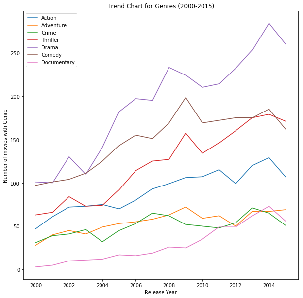

```python
#Plot the trend in adoption of genres from 2000 onwards
df_gen2.groupby('release_year')[selected_genres].sum().plot(figsize=(10,10))
plt.xlabel("Release Year")
plt.ylabel("Number of movies with Genre")
plt.title("Trend Chart for Genres (2000-2015)");
```

### Conclusions (2):

Among the selected genres 'Drama' has been one of the most adapted genre since 2000. However, documentary movies have witnessed the highest growth since 2000

### Limitations (2):

We must note that our insights and analysis have certain limitations to them. First, our analysis is limited to the database (which may not be exhaustive to include all released movies) and the insight may or may not apply to a real world scenario. Also, this analysis is limited only for movies since 2000 and only to a selected set of genres (However, this is flexible and analyis can be modified to inlcude any genre as required)